# DAXM wires calibration: crude from the Laue spots dips, fine with the fluorescence

The wires trajectory parameters (`.calib` file: `h`, `p0`, `f1`, `f2`, `R` of each wire, `u1`, `u2`) are needed to convert the dips of the Laue spots (quick daxm) or the shadowed intensities (reconstruction) into positions of the sources along the beam.

[output not shown]

The wire scans of the same sample folder use this calibration automatically (`CALIBFILE = 'auto'` in `2_quick_daxm` and `3_quick_daxm_grid`): the refined one if done, else the crude one.

**Depth zero of each calibration**: `dips` (Ge): the mean depth of the Ge Laue spots; `envelope`: the shallowest grains (e.g. top of a coating); fluorescence: the top of the fluorescent element (e.g. Zr below a Cr coating if the Cr fluorescence is cut by the detector energy threshold). Step 6 shows the shift between them.

Core functions: `LaueTools/Daxm/quickdaxm.py`, `LaueTools/daxm_workflow.py`; fluorescence refinement: legacy `CalibFluo` (`LaueTools/Daxm/classes/calibration`).

# SETTINGS

```python
# 1. experiment and wire scan of the calibration
RAW_DATA_FOLDER = '/data/visitor/<proposal>/bm32/<date>/RAW_DATA'
SCAN_FILTER = '<sample>_grid'  # words of the dataset name ('-word': without it); '': all wire scans
SCAN_INDEX = '<sample>_grid_index_0_row_col_0_0_1'  # None: menu of STEP 1; or index in the table or dataset name
MODE = 'compute'           # 'compute'; 'show': only show existing results
DETFILE = 'auto'           # detector calibration .det file; 'auto': the last one acquired before the scan

# 2. crude calibration from the dips of the Laue spots (STEP 4)
CRUDE_METHOD = 'auto'      # 'dips' (Ge: sources at the surface), 'envelope' (sample: shallowest grains = depth 0),
                           # 'auto': 'dips' for a Ge scan (Ge in the dataset name), else 'envelope'
NB_WIRES = None            # nb of wires (None: all the bands of dips found)
RADIUS_EACH_WIRE = False   # 'dips': radius of each wire fitted (wires of different diameters)
ENVELOPE_OUTLIERS = 0.02   # 'envelope': fraction of the dips of a wire allowed beyond its envelope line
EXCLUDED_WIRES = None      # wires whose dips give no depth (kept in the .calib: their shadows are known), e.g. [3]

# 3. fine calibration with the fluorescence (STEP 5)
CHECK_FLUO_PROFILES = True # plots of the fluorescence profiles used by the refinement (~1 min)
REPLACE_BAD_POINTS = True  # unusable profiles (Laue spot in the box, dip cut by the scan, not a fluorescence dip)
                           # replaced by usable ones probed nearby (along X first), in the check and the refinement
PROBE_ALL_POINTS = False   # True: every point probed (moved only if its profile is clearly better)
FLUO_RESOLUTION = False    # blur of the fluorescence dips with the refined wires (depth resolution, ~1 min)
REFINE_FLUO = False        # refinement (several minutes per stage)
FLUO_ELEMENT = 'Zr'        # fluorescent element of the scanned sample (Ge for a Ge crystal)
FLUO_THICKNESS = 0.3       # mm, thickness of the fluorescent layer (model of the source)
FLUO_LAYER = 0.025         # mm along the beam: layer above the fluorescent material whose signal passes the detector
                           # threshold (Cr coating on Zr: ~0.025), fitted with the wires; None: no layer (Ge)
FLUO_WIRES = None          # wires refined, e.g. [0, 1, 2] (the others keep their crude parameters, excluded); None: all
FLUO_STAGES = 3            # nb of stages of the refinement: 1 (2x2 points per wire), 2 (3x3), 3 (6x6)
FLUO_RESOURCE = 'kernel'   # where the refinement runs: 'kernel' (this notebook), 'local' (background process here),
                           # 'magnifix' (SLURM job, 192 cpus for the jacobian); the notebook waits for the result

# 4. computation and files
QUICKDAXM = {'skip_images': 40}  # changes of the quick daxm parameters. skip_images: first images of the scans not used
                           # (Zr5 grid: wire position wrong by ~8 µm in images 0-39 of the scans after the first one,
                           # see mismatch_vs_image())
NB_CPUS = None             # None: all available cpus
REDO = False               # True: compute again the quick daxm of the scan
OUTPUT_ROOT = None         # None: PROCESSED_DATA of the experiment; or another folder for the results
```

# IMPORTS

```python
from pathlib import Path
import numpy as np
import matplotlib.pyplot as plt
try:
    import ipympl  # interactive plots (zoom, hover) in JupyterLab / VS Code
    %matplotlib widget
except ImportError:
    %matplotlib inline
from IPython.display import display

import LaueTools.daxm_workflow as DW
import LaueTools.Daxm.quickdaxm as QD
import LaueTools.generaltools as GT
```

```
Using 'cumulative_trapezoid' as 'cumtrapz' (newer SciPy version)
sys.version in source.py 3.12.14 | packaged by conda-forge | (main, Aug 21 2026, 22:48:28) [GCC 14.4.0]
```

# STEP 1: wire scan of the calibration

A Ge wire scan (reference crystal), or a wire scan of the sample (its own Laue spots dips, its own fluorescence). `done`: results already there (`wires:dips`, `wires:envelope`, `wires:fluo`: calibrations made with this scan).

```python
wirescans = DW.list_wire_scans(RAW_DATA_FOLDER, contains=SCAN_FILTER, output_root=OUTPUT_ROOT)
DW.show_wire_scans(wirescans)
```

```
392 wire scans in 392 datasets of /data/visitor/<proposal>/bm32/<date>/RAW_DATA (0.6 s)
```

|  | dataset | start | command | points | images | end | done |
| --- | --- | --- | --- | --- | --- | --- | --- |
| 0 | _grid_index_0_row_col_0_0_1 | 2026-07-12T16:34:38.302718+02:00 | fscan zf 4.591 0.001 401 0.3 0.300012 | 401 | 401 files | SUCCESS | config, quickdaxm, slices:25, wires:fluo, wires:envelope |
| 1 | _1 | 2026-07-12T16:36:51.929760+02:00 | fscan zf 4.591 0.001 401 0.3 0.300012 | 401 | 401 files | SUCCESS | config, quickdaxm, wires:envelope |
| 2 | _grid_index_2_row_col_0_2_1 | 2026-07-12T16:39:04.757197+02:00 | fscan zf 4.591 0.001 401 0.3 0.300012 | 401 | 401 files | SUCCESS |  |
| 3 | _grid_index_3_row_col_0_3_1 | 2026-07-12T16:41:19.885473+02:00 | fscan zf 4.591 0.001 401 0.3 0.300012 | 401 | 401 files | SUCCESS |  |
| 4 | _grid_index_4_row_col_0_4_1 | 2026-07-12T16:43:33.218273+02:00 | fscan zf 4.591 0.001 401 0.3 0.300012 | 401 | 401 files | SUCCESS |  |
| 5 | _grid_index_5_row_col_0_5_1 | 2026-07-12T16:45:46.418442+02:00 | fscan zf 4.591 0.001 401 0.3 0.300012 | 401 | 401 files | SUCCESS |  |
| 6 | _grid_index_6_row_col_0_6_1 | 2026-07-12T16:47:59.888929+02:00 | fscan zf 4.591 0.001 401 0.3 0.300012 | 401 | 401 files | SUCCESS |  |
| 7 | _grid_index_7_row_col_0_7_1 | 2026-07-12T16:50:14.694356+02:00 | fscan zf 4.591 0.001 401 0.3 0.300012 | 401 | 401 files | SUCCESS |  |
| 8 | _grid_index_8_row_col_0_8_1 | 2026-07-12T16:52:28.226185+02:00 | fscan zf 4.591 0.001 401 0.3 0.300012 | 401 | 401 files | SUCCESS |  |
| 9 | _grid_index_9_row_col_0_9_1 | 2026-07-12T16:54:41.244100+02:00 | fscan zf 4.591 0.001 401 0.3 0.300012 | 401 | 401 files | SUCCESS |  |
| 10 | _grid_index_10_row_col_0_10_1 | 2026-07-12T16:56:56.517268+02:00 | fscan zf 4.591 0.001 401 0.3 0.300012 | 401 | 401 files | SUCCESS |  |
| 11 | _grid_index_11_row_col_0_11_1 | 2026-07-12T16:59:09.613006+02:00 | fscan zf 4.591 0.001 401 0.3 0.300012 | 401 | 401 files | SUCCESS |  |
| 12 | _grid_index_12_row_col_0_12_1 | 2026-07-12T17:01:22.946722+02:00 | fscan zf 4.591 0.001 401 0.3 0.300012 | 401 | 401 files | SUCCESS |  |
| 13 | _grid_index_13_row_col_0_13_1 | 2026-07-12T17:03:35.894828+02:00 | fscan zf 4.591 0.001 401 0.3 0.300012 | 401 | 401 files | SUCCESS |  |
| 14 | _grid_index_14_row_col_0_14_1 | 2026-07-12T17:05:49.024275+02:00 | fscan zf 4.591 0.001 401 0.3 0.300012 | 401 | 401 files | SUCCESS |  |
| 15 | _grid_index_15_row_col_0_15_1 | 2026-07-12T17:08:02.169389+02:00 | fscan zf 4.591 0.001 401 0.3 0.300012 | 401 | 401 files | SUCCESS |  |
| 16 | _grid_index_16_row_col_0_16_1 | 2026-07-12T17:10:15.431896+02:00 | fscan zf 4.591 0.001 401 0.3 0.300012 | 401 | 401 files | SUCCESS |  |
| 17 | _grid_index_17_row_col_0_17_1 | 2026-07-12T17:12:30.085368+02:00 | fscan zf 4.591 0.001 401 0.3 0.300012 | 401 | 401 files | SUCCESS |  |
| 18 | _grid_index_18_row_col_0_18_1 | 2026-07-12T17:14:43.477545+02:00 | fscan zf 4.591 0.001 401 0.3 0.300012 | 401 | 401 files | SUCCESS |  |
| 19 | _grid_index_19_row_col_0_19_1 | 2026-07-12T17:16:57.103219+02:00 | fscan zf 4.591 0.001 401 0.3 0.300012 | 401 | 401 files | SUCCESS |  |
| 20 | _grid_index_20_row_col_0_20_1 | 2026-07-12T17:19:10.207840+02:00 | fscan zf 4.591 0.001 401 0.3 0.300012 | 401 | 401 files | SUCCESS |  |
| 21 | _grid_index_21_row_col_0_21_1 | 2026-07-12T17:21:25.132671+02:00 | fscan zf 4.591 0.001 401 0.3 0.300012 | 401 | 401 files | SUCCESS |  |
| 22 | _grid_index_22_row_col_0_22_1 | 2026-07-12T17:23:38.163811+02:00 | fscan zf 4.591 0.001 401 0.3 0.300012 | 401 | 401 files | SUCCESS |  |
| 23 | _grid_index_23_row_col_0_23_1 | 2026-07-12T17:25:51.301865+02:00 | fscan zf 4.591 0.001 401 0.3 0.300012 | 401 | 401 files | SUCCESS |  |
| 24 | _grid_index_24_row_col_0_24_1 | 2026-07-12T17:28:06.719366+02:00 | fscan zf 4.591 0.001 401 0.3 0.300012 | 401 | 401 files | SUCCESS |  |
| 25 | _grid_index_25_row_col_0_25_1 | 2026-07-12T17:30:20.329754+02:00 | fscan zf 4.591 0.001 401 0.3 0.300012 | 401 | 401 files | SUCCESS |  |
| 26 | _grid_index_26_row_col_0_26_1 | 2026-07-12T17:32:33.378707+02:00 | fscan zf 4.591 0.001 401 0.3 0.300012 | 401 | 401 files | SUCCESS |  |
| 27 | _grid_index_27_row_col_0_27_1 | 2026-07-12T17:34:46.390286+02:00 | fscan zf 4.591 0.001 401 0.3 0.300012 | 401 | 401 files | SUCCESS |  |
| 28 | _grid_index_28_row_col_1_0_1 | 2026-07-12T17:37:10.847871+02:00 | fscan zf 4.591 0.001 401 0.3 0.300012 | 401 | 401 files | SUCCESS |  |
| 29 | _grid_index_29_row_col_1_1_1 | 2026-07-12T17:39:24.156263+02:00 | fscan zf 4.591 0.001 401 0.3 0.300012 | 401 | 401 files | SUCCESS |  |

[output cut: 362 more lines]

```python
selector = DW.WireScanSelector(wirescans, SCAN_INDEX)
```

```
-- warning: sklearn.metrics is not installed. For matchingrate.py module, it could be useful... but not necessary
-- WARNING: module Image or PIL is not installed, but only used for templateimagematching
hostname = hpc6-01
```

```
[interactive widget (ipywidgets)]
```

# STEP 2: settings file (without wires calibration)

```python
index = selector.index
row = wirescans.loc[index]
print(f"scan {index}: {row['dataset']}  {row['command']}  ({row['end']})")
if MODE == 'show':
    cfg = DW.load_config(Path(row['workdir']) / 'configs' / 'daxm.yaml')
else:
    cfg = DW.config_for_scan(wirescans, index, detfile=DETFILE, calibfile=None, nb_cpus=NB_CPUS, **QUICKDAXM)
cfg['wirescalib']['fluo_element'] = FLUO_ELEMENT
cfg['wirescalib']['fluo_thickness'] = FLUO_THICKNESS
cfg['wirescalib']['fluo_layer'] = FLUO_LAYER
method = CRUDE_METHOD if CRUDE_METHOD != 'auto' else ('dips' if DW.is_reference_scan(row['dataset']) else 'envelope')
print('results folder:', cfg['output']['folder'])
print('crude calibration method:', method)
```

```
scan 1: <dataset>_1  fscan zf 4.591 0.001 401 0.3 0.300012  (SUCCESS)
calibration: /data/visitor/<proposal>/bm32/<date>/RAW_DATA/<sample>/<dataset>/scan0001/calibGe001.det (acquired 2026-07-08 09:39, map started 2026-07-12T16:36:51.929760+02:00)
daxm configuration: /data/visitor/<proposal>/bm32/<date>/PROCESSED_DATA/<sample>/<dataset>/scan0001/daxm/configs/daxm.yaml
results folder: /data/visitor/<proposal>/bm32/<date>/PROCESSED_DATA/<sample>/<dataset>/scan0001/daxm
crude calibration method: envelope
```

# STEP 3: dips of the Laue spots (quick daxm without wires calibration)

Blue: profile of a spot minus its local background, red/green: entry/exit edges of the dips. Orange: local background (fluorescence: its smooth dips are the data of the fine calibration, STEP 5).

```python
MODE
```

```
'compute'
```

```
quick daxm already done: results reloaded from /data/visitor/<proposal>/bm32/<date>/PROCESSED_DATA/<sample>/<dataset>/scan0001/daxm/quickdaxm.h5
(redo=True to compute again)
2000 spots, 1815 dips
```

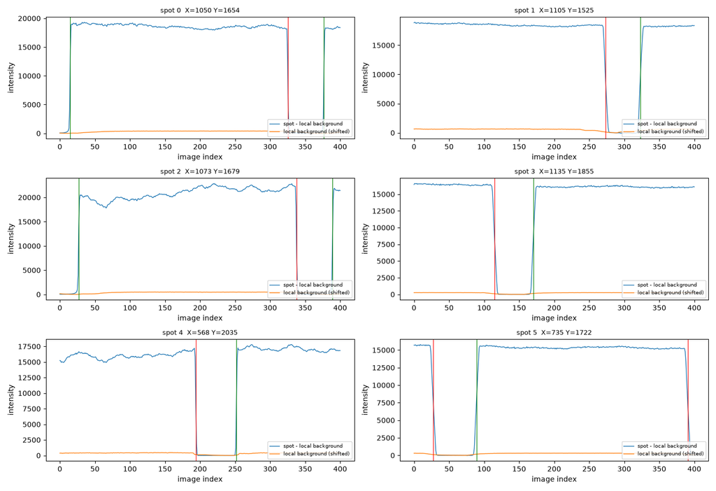

```python
if MODE == 'show':
    results = DW.load_quickdaxm(cfg)
else:
    results = DW.run_quickdaxm(cfg, resource='kernel', nb_cpus=NB_CPUS, redo=REDO)
print(f"{len(results['spots']['X'])} spots, {len(results['dips']['spot'])} dips")

SPOTS = list(range(6))
plt.close('all')
fig, axes = plt.subplots(len(SPOTS) // 2, 2, figsize=(14, 3.2 * (len(SPOTS) // 2)))
for ax, spot in zip(axes.ravel(), SPOTS):
    QD.plot_profile(results, spot, ax)
fig.tight_layout()
plt.show()
```

# STEP 4: crude calibration from the dips of the Laue spots

- `dips` (Ge): the dips of each wire lie on a band of the plot *image index of dip* vs *pixel Y*; least squares fit of `h`, `p0`, `f1` of each wire and `R` to the dips edges, all the sources at `ybeam = 0`
- `envelope` (any sample): for each band, the line beyond which there are no dips (only `ENVELOPE_OUTLIERS` of them): the shallowest grains of the region of the detector of the wire are at `ybeam = 0`. Right plot: vertical distance of the dips to the line of their wire (images, about microns along the beam for a step of 1 µm): sharp start at 0 expected

Wire 0: largest pixel Y of its shadow (closest to the sample surface). A wire seen during a part of the scan only has few dips: check it, exclude it (`EXCLUDED_WIRES`) if needed.

```
1432 dips assigned to 4 wires; envelope: shadow lines of the wires (h per wire) (2 % of the dips of each wire allowed beyond)
  wire 0: h 0.7963 mm  p0 4.2860 mm  f1 -0.10 deg  f2 +0.15 deg  (265 dips)
  wire 1: h 0.8016 mm  p0 4.6414 mm  f1 -0.35 deg  f2 +0.10 deg  (541 dips)
  wire 2: h 0.7915 mm  p0 4.9646 mm  f1 -0.60 deg  f2 -1.00 deg  (449 dips)
  wire 3: h 0.7708 mm  p0 5.2915 mm  f1 -0.70 deg  f2 +0.10 deg  (177 dips)
  R 24.45 microns (from the widths of the dips)  u1 = u2 = 0
crude wires calibration (envelope): /data/visitor/<proposal>/bm32/<date>/PROCESSED_DATA/<sample>/<dataset>/scan0001/daxm/wirescalib/wires_from_envelope.calib
```

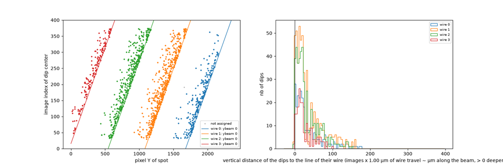

```python
plt.close('all')
if MODE != 'show':
    crude = DW.crude_wires(cfg, results, method, nb_wires=NB_WIRES, radius_each_wire=RADIUS_EACH_WIRE,
                           outliers=ENVELOPE_OUTLIERS, excluded_wires=EXCLUDED_WIRES)
    crude_calib = crude['calibfile']
    if method == 'envelope':
        QD.plot_envelope(results, crude)
else:
    crude_calib = str(Path(DW.calib_files(cfg)['folder']) / ('wires_from_dips.calib' if method == 'dips' else 'wires_from_envelope.calib'))
plt.show()
```

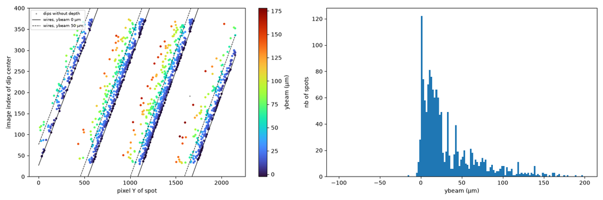

```python
# dips colored by their position along the beam with the crude wires, and wires lines for ybeam 0 and 50 µm
plt.close('all')
check = dict(results, calibfile=crude_calib)
check['dips'], check['spots'] = QD.analyse(results['signal'], results['xy'], QD.geometry_of_results(check), results['params'])
fig, axes = plt.subplots(1, 2, figsize=(15, 5))
QD.plot_abacus(check, axes[0], ybeams=(0, 50))
QD.plot_histogram(check, axes[1], step=2.)
fig.tight_layout()
plt.show()
```

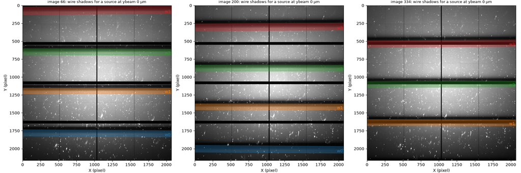

```python
IMAGES = None   # image indices of the Laue patterns shown with the predicted shadows (None: 3 images of the scan)

plt.close('all')
geometry = QD.WireGeometry.from_files(crude_calib, cfg['detector']['detfile'], results['wire_positions'])
nbimages = len(results['wire_positions'])
images = IMAGES or [nbimages // 6, nbimages // 2, 5 * nbimages // 6]
fig, axes = plt.subplots(1, len(images), figsize=(6 * len(images), 6))
for ax, imageindex in zip(np.atleast_1d(axes), images):
    QD.plot_image_shadows(cfg['scan'], geometry, imageindex, ax=ax)
fig.tight_layout()
plt.show()
```

# STEP 5: fine calibration with the fluorescence (option)

**Check of the profiles** (`CHECK_FLUO_PROFILES`): the fluorescence intensity profiles that the refinement will fit, at the points of a 3x3 grid per wire, in the windows of wire positions predicted by the crude wires. Each profile is fitted by the template of a fluorescence dip (sharp edge on the side of the surface, exponential tail of the deeper sources, shadow width predicted by the wires at this pixel). Usable (green): no Laue spot near the box, deep enough dip, above the noise, complete in its window, small residual of the template (it looks like a fluorescence dip), no spike, sharp edge close to the predicted one, shadow width close to the predicted one. With `REPLACE_BAD_POINTS`, an unusable point is replaced by the best usable point probed nearby, along X first at the same Y (as the background pixels of the PixelMonitoring notebooks), then towards the middle of the shadow region of the wire; the refinement uses the same replacements. Points still red are listed with the reason. A layered sample may show 2 dips (e.g. Cr coating and Zr below), unless one fluorescence is cut by the energy threshold of the detector: the model has one fluorescent element (`FLUO_ELEMENT`).

**Refinement** (`REFINE_FLUO`): `FLUO_STAGES` stages of `calib.py` (2x2, 3x3, 6x6 points per wire), starting from the crude wires. Fast optimizer (`LaueTools/Daxm/fastcalib.py`): same model and results, the amplitudes of the profiles solved exactly and the jacobian computed in parallel; `FLUO_RESOURCE = 'magnifix'` runs it as a SLURM job on a node of 192 cpus. The refined .calib file is the reference for the other scans of the sample: notebook 2 (`LOCAL_FLUO_REFINE`) or `DW.refine_wires_local()` refine only p0 (or h, p0) at another place, in seconds. With `FLUO_LAYER` (coated sample, e.g. Cr on Zr), the model has a uniform layer above the fluorescent material, whose thickness (common) and fraction of the signal (per profile) are fitted with the wires (`LaueTools/Daxm/fluolayer.py`); they are written in the .calib files (key `fluo_layer`). Without it, the signal of the layer pulls the depth zero towards the surface (~1.3 µm for Zr5) and blurs the edges of the dips. `FLUO_WIRES = [0, 1, 2]`: only these wires refined, the others keep their crude parameters and are excluded from the depth analysis and the reconstruction.

```python
plt.close('all')
if CHECK_FLUO_PROFILES and MODE != 'show':
    profiles_table = DW.check_fluo_profiles(cfg, crude_calib, dims=(3, 3), replace_bad_points=REPLACE_BAD_POINTS,
                                            probe_all=PROBE_ALL_POINTS)
    display(profiles_table)
plt.show()
```

[output not shown]

```
<inhouse path>:1324: UserWarning: Tight layout not applied. tight_layout cannot make Axes width small enough to accommodate all Axes decorations
  fig.tight_layout()
```

|  | wire | point | X | Y | nb | contrast | snr | complete | spikes | rms | offset | width | width_pred | length | tail | spot_in_box | ok | replaced |
| --- | --- | --- | --- | --- | --- | --- | --- | --- | --- | --- | --- | --- | --- | --- | --- | --- | --- | --- |
| 0 | 0 | 0 | 862 | 1830 | 243 | 0.855154 | 39.569451 | True | 0 | 0.027878 | 20.232507 | 55.021083 | 54.681008 | 15.999674 | 1 | False | True | True |
| 1 | 0 | 1 | 1014 | 1830 | 243 | 0.856534 | 32.565479 | True | 0 | 0.029536 | 20.686501 | 55.361927 | 54.664511 | 16.011271 | 1 | False | True | False |
| 2 | 0 | 2 | 1551 | 1830 | 240 | 0.868392 | 31.538024 | True | 0 | 0.032205 | 22.920313 | 55.261686 | 54.606466 | 16.226731 | 1 | False | True | False |
| 3 | 0 | 3 | 517 | 1940 | 301 | 0.851546 | 29.192811 | True | 0 | 0.037498 | 17.655163 | 58.207811 | 56.668376 | 14.345244 | 1 | False | True | False |
| 4 | 0 | 4 | 1014 | 1940 | 301 | 0.853741 | 33.240612 | True | 0 | 0.032833 | 19.776340 | 58.002829 | 56.605387 | 15.194471 | 1 | False | True | False |
| 5 | 0 | 5 | 1551 | 1940 | 301 | 0.867495 | 24.534737 | True | 0 | 0.039048 | 22.474064 | 58.015323 | 56.537701 | 14.165337 | 1 | False | True | False |
| 6 | 0 | 6 | 517 | 2050 | 304 | 0.869980 | 24.942290 | True | 0 | 0.042743 | 17.907486 | 59.291176 | 58.839862 | 12.818825 | 1 | False | True | False |
| 7 | 0 | 7 | 1014 | 2050 | 304 | 0.857713 | 25.607464 | True | 0 | 0.039491 | 19.437279 | 59.733015 | 58.768208 | 13.972545 | 1 | False | True | False |
| 8 | 0 | 8 | 1551 | 2050 | 303 | 0.858339 | 22.212116 | True | 0 | 0.046792 | 21.584053 | 59.798750 | 58.691167 | 13.436705 | 1 | False | True | False |
| 9 | 1 | 0 | 517 | 1270 | 259 | 0.824602 | 43.699732 | True | 0 | 0.022624 | 18.605579 | 49.336293 | 49.041826 | 19.199637 | 1 | False | True | False |
| 10 | 1 | 1 | 1100 | 1313 | 285 | 0.845568 | 46.230973 | True | 0 | 0.017883 | 19.977209 | 49.456327 | 49.186354 | 18.839767 | 1 | False | True | True |
| 11 | 1 | 2 | 1551 | 1270 | 258 | 0.825870 | 43.162151 | True | 0 | 0.022243 | 20.820091 | 49.077899 | 49.038891 | 17.898873 | 1 | False | True | False |
| 12 | 1 | 3 | 517 | 1414 | 294 | 0.842491 | 42.284600 | True | 0 | 0.022143 | 19.405217 | 49.528890 | 49.732055 | 17.291196 | 1 | False | True | False |
| 13 | 1 | 4 | 1014 | 1414 | 294 | 0.833587 | 48.919785 | True | 0 | 0.019064 | 19.686377 | 49.412677 | 49.728032 | 17.819084 | 1 | False | True | False |
| 14 | 1 | 5 | 1551 | 1414 | 295 | 0.834203 | 38.127139 | True | 0 | 0.025979 | 20.120573 | 49.746170 | 49.723703 | 17.616679 | 1 | False | True | False |
| 15 | 1 | 6 | 517 | 1558 | 262 | 0.842258 | 41.007091 | True | 0 | 0.023548 | 18.724220 | 50.504728 | 50.971573 | 17.425117 | 1 | False | True | False |
| 16 | 1 | 7 | 1014 | 1558 | 263 | 0.837412 | 48.327404 | True | 0 | 0.021658 | 18.724276 | 50.483362 | 50.964331 | 17.846959 | 1 | False | True | False |
| 17 | 1 | 8 | 1551 | 1558 | 263 | 0.845495 | 35.845662 | True | 0 | 0.025734 | 19.579432 | 50.688789 | 50.956531 | 17.332429 | 1 | False | True | False |
| 18 | 2 | 0 | 517 | 731 | 263 | 0.840401 | 40.159546 | True | 0 | 0.020226 | 19.053342 | 51.671054 | 51.449167 | 19.705023 | 1 | False | True | False |
| 19 | 2 | 1 | 1014 | 731 | 262 | 0.837564 | 45.572494 | True | 0 | 0.017501 | 20.767997 | 51.594991 | 51.461682 | 19.583581 | 1 | False | True | False |
| 20 | 2 | 2 | 1551 | 731 | 261 | 0.822588 | 43.330133 | True | 0 | 0.028505 | 20.991438 | 51.960808 | 51.475421 | 20.998677 | 1 | False | True | False |
| 21 | 2 | 3 | 517 | 878 | 294 | 0.837172 | 41.076729 | True | 0 | 0.020334 | 18.768321 | 50.336588 | 50.045118 | 18.974437 | 1 | False | True | False |
| 22 | 2 | 4 | 1014 | 878 | 294 | 0.831653 | 51.017398 | True | 0 | 0.018262 | 20.022589 | 49.828164 | 50.046292 | 19.415940 | 1 | False | True | False |
| 23 | 2 | 5 | 1551 | 878 | 294 | 0.840184 | 42.384781 | True | 0 | 0.022119 | 21.023222 | 49.818837 | 50.047579 | 19.674887 | 1 | False | True | False |
| 24 | 2 | 6 | 517 | 1025 | 260 | 0.818764 | 42.492465 | True | 0 | 0.026668 | 18.092090 | 49.876608 | 49.184586 | 18.479893 | 1 | False | True | False |
| 25 | 2 | 7 | 1014 | 1025 | 260 | 0.829339 | 49.239364 | True | 0 | 0.017930 | 19.210608 | 48.577808 | 49.181444 | 19.150702 | 1 | False | True | False |
| 26 | 2 | 8 | 1292 | 981 | 286 | 0.831559 | 51.411082 | True | 0 | 0.017412 | 19.874371 | 49.324769 | 49.378853 | 19.030431 | 1 | False | True | True |
| 27 | 3 | 0 | 517 | 158 | 269 | 0.882099 | 38.939502 | True | 0 | 0.025708 | 19.608163 | 61.487503 | 61.382581 | 19.810421 | 1 | False | True | False |
| 28 | 3 | 1 | 1014 | 158 | 270 | 0.876716 | 39.996893 | True | 0 | 0.023230 | 19.346573 | 60.964592 | 61.310121 | 19.619465 | 1 | False | True | False |
| 29 | 3 | 2 | 1551 | 158 | 272 | 0.865294 | 36.329952 | True | 0 | 0.026104 | 18.009791 | 61.662177 | 61.232106 | 19.826475 | 1 | False | True | False |
| 30 | 3 | 3 | 517 | 306 | 303 | 0.861449 | 40.884866 | True | 0 | 0.022036 | 20.987438 | 57.977088 | 58.280586 | 19.447409 | 1 | False | True | False |
| 31 | 3 | 4 | 1014 | 306 | 303 | 0.833096 | 38.480883 | True | 0 | 0.026876 | 19.531287 | 58.200240 | 58.217289 | 16.776496 | 1 | False | True | False |
| 32 | 3 | 5 | 1551 | 306 | 303 | 0.829809 | 36.519466 | True | 0 | 0.026389 | 18.460729 | 57.545001 | 58.149178 | 23.693111 | 1 | False | True | False |
| 33 | 3 | 6 | 517 | 454 | 265 | 0.848331 | 49.962030 | True | 0 | 0.021349 | 21.451602 | 55.197869 | 55.526429 | 19.179601 | 1 | False | True | False |
| 34 | 3 | 7 | 1014 | 410 | 289 | 0.859127 | 46.311096 | True | 0 | 0.018962 | 20.056615 | 56.012176 | 56.249169 | 19.861599 | 1 | False | True | True |
| 35 | 3 | 8 | 1551 | 454 | 261 | 0.854888 | 43.346812 | True | 0 | 0.022739 | 19.452564 | 55.825098 | 55.415551 | 19.401936 | 1 | False | True | False |

```python
REFINE_FLUO
```

```
False
```

```python
REFINE_FLUO = True


fine_calib = None
if REFINE_FLUO and MODE != 'show':
    stages = DW.refine_wires_fluo_job(cfg, resource=FLUO_RESOURCE, nb_cpus=NB_CPUS, init_calib=crude_calib,
                                      stages=DW.FLUO_STAGES[:FLUO_STAGES], wires=FLUO_WIRES,
                                      excluded_wires=EXCLUDED_WIRES, replace_bad_points=REPLACE_BAD_POINTS,
                                      probe_all=PROBE_ALL_POINTS)
    for stage in stages:
        print(f"stage {stage['stage']} {stage['dims']}: GoF {stage['gof']:.2f}, fitted depth dm {stage['dm']}, "
              f"{stage['seconds']:.0f} s -> {stage['calibfile']}")
    fine_calib = stages[-1]['calibfile']
else:
    previous = sorted(Path(DW.calib_files(cfg)['folder']).glob('*_stage*.calib'), key=lambda p: p.stat().st_mtime)
    fine_calib = str(previous[-1]) if previous else None
print('fine calibration:', fine_calib)
```

[output not shown]

[output cut: 250 more lines]

```
[calib]     | 0.000012  0.000365  0.000139  0.000414  0.000778  0.000000  0.000334
[calib]  #2 | 0.024631  0.801656  4.662712  -0.150403  1.150040  0.000000  -0.055384
[calib]     | 0.000006  0.000107  0.000013  0.000074  0.000292  0.000000  0.000334
[calib]  #3 | 0.024569  0.778283  4.982170  -0.547198  0.125365  0.000000  -0.055384
[calib]     | 0.000006  0.000147  0.000022  0.000042  0.000173  0.000000  0.000334
[calib]  #4 | 0.024535  0.771401  5.312644  -2.969018  -3.841704  0.000000  -0.055384
[calib]     | 0.000010  0.000363  0.000133  0.000157  0.000224  0.000000  0.000334
[calib] and fitted depth = 0.107310 +- 0.001248
fast calibration: 23 variables, 51 evaluations, 46 jacobians, 24 processes, 102 s
[calib] Saving wire parameters to: /data/visitor/<proposal>/bm32/<date>/PROCESSED_DATA/<sample>/<dataset>/scan0001/daxm/wirescalib/wires_fluo_stage3.calib
stage 3: GoF 1.92 (115 s) -> /data/visitor/<proposal>/bm32/<date>/PROCESSED_DATA/<sample>/<dataset>/scan0001/daxm/wirescalib/wires_fluo_stage3.calib; layer 7.57 um along the beam, 6.6 % of the signal
stage 1 [2, 2]: GoF 1.45, fitted depth dm 0.12439147985580702, 19 s -> /data/visitor/<proposal>/bm32/<date>/PROCESSED_DATA/<sample>/<dataset>/scan0001/daxm/wirescalib/wires_fluo_stage1.calib
stage 2 [3, 3]: GoF 1.43, fitted depth dm 0.12586594678301985, 22 s -> /data/visitor/<proposal>/bm32/<date>/PROCESSED_DATA/<sample>/<dataset>/scan0001/daxm/wirescalib/wires_fluo_stage2.calib
stage 3 [6, 6]: GoF 1.92, fitted depth dm 0.10730997748168444, 115 s -> /data/visitor/<proposal>/bm32/<date>/PROCESSED_DATA/<sample>/<dataset>/scan0001/daxm/wirescalib/wires_fluo_stage3.calib
fine calibration: /data/visitor/<proposal>/bm32/<date>/PROCESSED_DATA/<sample>/<dataset>/scan0001/daxm/wirescalib/wires_fluo_stage3.calib
```

**Depth resolution** (`FLUO_RESOLUTION`): each fluorescence profile fitted with the refined wires fixed, by the source model blurred by a gaussian: blur sigma (instrument: beam, wire edge, pixel) and shift (local error of the calibration), in microns along the beam. For a single element reference (Ge) sigma is the instrument resolution; for a layered sample (Cr on Zr) the single source model is incomplete and sigma is an upper bound.

```python
plt.close('all')
if FLUO_RESOLUTION and fine_calib and MODE != 'show':
    resolution_table = DW.fluo_resolution(cfg, fine_calib, dims=(3, 3), replace_bad_points=REPLACE_BAD_POINTS)
    display(resolution_table.round(2))
plt.show()
```

# STEP 6: comparison of the calibrations

Wires parameters and positions along the beam of the Laue spots of this scan with each calibration (same dips). The shift of the median `ybeam` between two calibrations is the difference of their depth zeros, e.g. `envelope` (shallowest grains: top of a coating) vs fluorescence (top of the fluorescent element). The `2-wire spread` (spots masked by 2 wires) and the `mismatch` (entry vs exit edges) check the consistency of a calibration.

|  | calibration | wire | excluded | h | p0 | R (µm) | f1 | f2 | u2 | dips with depth | median ybeam (µm) | median mismatch (µm) | spots with depth | median 2-wire spread (µm) |
| --- | --- | --- | --- | --- | --- | --- | --- | --- | --- | --- | --- | --- | --- | --- |
| 0 | crude (envelope) | 0 | False | 0.7963 | 4.2860 | 24.4482 | -0.1000 | 0.1500 | 0.0000 | 344 | 20.4079 | 0.4113 | 1484 | 2.9868 |
| 1 | crude (envelope) | 1 | False | 0.8016 | 4.6414 | 24.4482 | -0.3500 | 0.1000 | 0.0000 | 676 | 20.8555 | 0.7558 | 1484 | 2.9868 |
| 2 | crude (envelope) | 2 | False | 0.7915 | 4.9646 | 24.4482 | -0.6000 | -1.0000 | 0.0000 | 567 | 18.5861 | 0.6236 | 1484 | 2.9868 |
| 3 | crude (envelope) | 3 | False | 0.7708 | 5.2915 | 24.4482 | -0.7000 | 0.1000 | 0.0000 | 225 | 17.0322 | 0.5186 | 1484 | 2.9868 |
| 4 | fluorescence | 0 | False | 0.7903 | 4.3117 | 24.9781 | -0.5577 | 0.1581 | -0.0554 | 345 | -2.5333 | 1.6179 | 1484 | 5.0763 |
| 5 | fluorescence | 1 | False | 0.8017 | 4.6627 | 24.6312 | -0.1504 | 1.1500 | -0.0554 | 675 | -0.6114 | 1.1141 | 1484 | 5.0763 |
| 6 | fluorescence | 2 | False | 0.7783 | 4.9822 | 24.5690 | -0.5472 | 0.1254 | -0.0554 | 567 | -1.6857 | 0.8882 | 1484 | 5.0763 |
| 7 | fluorescence | 3 | False | 0.7714 | 5.3126 | 24.5348 | -2.9690 | -3.8417 | -0.0554 | 225 | -2.8645 | 0.7649 | 1484 | 5.0763 |

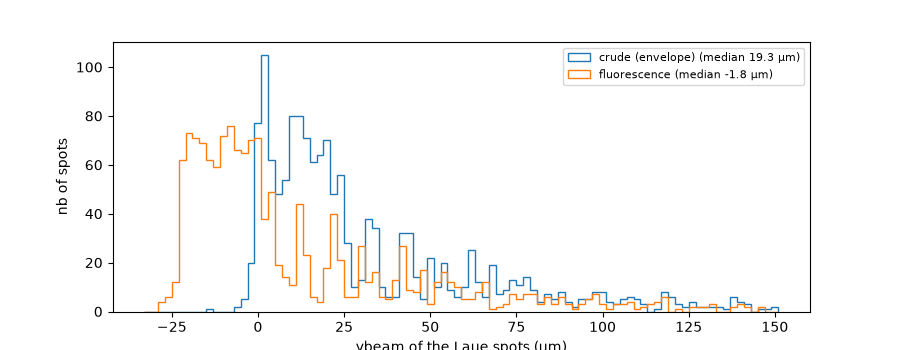

```python
plt.close('all')
calibrations = {f'crude ({method})': crude_calib}
if fine_calib:
    calibrations['fluorescence'] = fine_calib
comparison = DW.compare_calibrations(results, calibrations)
display(comparison.round(4))
plt.show()
```

# RESULT

The wire scans of the same sample folder use the calibration of this scan automatically (`CALIBFILE = 'auto'` in `2_quick_daxm` and `3_quick_daxm_grid`): the refined one if any, else the crude one. Or set `CALIBFILE` to one of the files printed below.

```python
DW.refresh_status(wirescans)
print('crude calibration      :', crude_calib)
print('fluorescence calibration:', fine_calib)
print('used by CALIBFILE = auto:', DW.existing_calibration(row['workdir']))
```

```
crude calibration      : /data/visitor/<proposal>/bm32/<date>/PROCESSED_DATA/<sample>/<dataset>/scan0001/daxm/wirescalib/wires_from_envelope.calib
fluorescence calibration: /data/visitor/<proposal>/bm32/<date>/PROCESSED_DATA/<sample>/<dataset>/scan0001/daxm/wirescalib/wires_fluo_stage3.calib
used by CALIBFILE = auto: /data/visitor/<proposal>/bm32/<date>/PROCESSED_DATA/<sample>/<dataset>/scan0001/daxm/wirescalib/wires_fluo_stage3.calib
```